# How to Play Maplestory Platformer

This game was made to resemble Maplestory, in which you jump on platforms and kill monsters.

**Author:** Tosca Beijaert  
**Year**: 2021  
**Copyright**: [MIT LICENSE](https://opensource.org/licenses/MIT)

## Table of Content

- Introduction
- How to start the game
- Files
  - main.py
  - Code folder
    - config.py
    - fighter.py
    - loading_spritesheets.py
    - player_attributes.py
    - terrain_objects.py
    - world.py
  - Static folder
    - img folder
    - Audio folder
    - level_data folder
  - LevelEditor folder
  - Test_package folder

### Introduction

Platform Game is a package that uses mostly [pygame](https://www.pygame.org/docs/) to create a game, which can then be played. For creating a game, various things need to be programmed to make it work.  
For example, a screen must be displayed, in here the game and players must be seen, key presses must be processed which allows for player movement, etc.

The most common imported functions & classes used are:

- **pygame.sprite.Sprite:** A simple base class for visible game objects, used to create Classes (e.g., enemy class)
- **[pygame.Rect](https://www.pygame.org/docs/ref/rect.html):** A pygame object for storing rectangular coordinates, which was used to get location of players and enemies.
- **pygame.Rect.colliderect:** Tests if two rectangles overlap, used to program player object interactions (e.g., walking into a wall).

Most important created classes are:

- `Fighter()`: See fighter.py section for more info.
- `HealthBar()`: See player_attributes.py section for more info.
- `Item()`: See terrain_objects.py section for more info.
- `TerrainObject()`: See terrain_objects.py section for more info

### How to start the game

To start the game, one only has to run the *main.py* file, see image underneath:

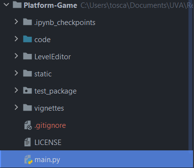

Once the game starts, press the start button to start the game.

[figure not shown]

To move use the arrow keys: the **up arrow** to climb up ropes (unfortunately I was not able to create this functionality yet, but will do so in the future),  
**down arrow** to climb down ropes (idem ditto), **left arrow** to move left, **right arrow** to move right and **spacebar** to jump.  
The goal is to reach the exit of the level. Whilst moving there, enemies will be on the road. Use **a** to slice  
enemies with your sword. If you have taken too much damage, look for healthboxes to regenerate! Just walking over them  
will suffice.

If you want to know more besides how to start the game, take a look at the following section in which the structure  
of the code is explained.

### Files

#### Main.py

The main.py is the file in which the code combines all the other code of the other files.Thus, this is the only code one has to  
run to start the game. The `def main_loop()` is the main function that allows the game to run and also interprets keypresses (e.g., 'space' = jump).

#### Code Folder

This folder contains some code necessary to run the game

##### $\qquad$Config.py

$\qquad$In the configuration script variables that are constants are given in CAPSLOCK (indicating that they are constants).  
$\qquad$Thus, the values of these should never be changed. For example, `SCREEN_WIDTH = 800`, or `GRAVITY = 0.75`,  
$\qquad$should not be changed, as this might make the game crash, see following image:  
$\qquad$

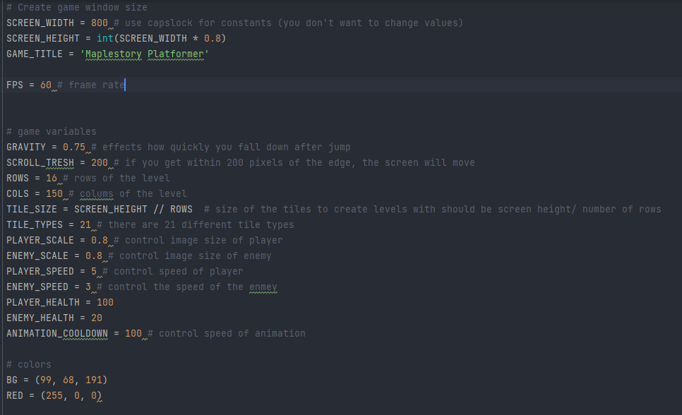

##### $\qquad$Figther.py

$\qquad$In the *figher.py*, the class `Fighter()` is created. In this class, based on the arguments given,  
$\qquad$either a player, or an enemy will be created. In this class are many functions (e.g., `def move()`,  
$\qquad$def `update_animation`) that allow the player to move or jump, to take damage, to update their animation,  
$\qquad$etc. For exact info on the functions in the class, see *fighter.py* or use `help(Figther.__requested_function__)`.

##### $\qquad$Loading_spritesheets.py

$\qquad$In this script, a spritesheet is given as input:

$\qquad$

[figure not shown]

$\qquad$A spritesheets contains different images for a game character, when doing different actions.  
$\qquad$For example, the first row is for standing still, the second row for moving, the third for being hit and the fourth for dying.  
$\qquad$This scripts loads the spritesheet, and creates and saves new image files for each seperate image.These will then be used in the game,  
$\qquad$dependent on what the player does (e.g., if player moves left, the moving images are shown). When played quickly after each other, an  
$\qquad$animation can be seen. Thus, if all images for moving (row 2) are displayed, it will appear like the player is moving.

$\qquad$This script was created by [russ123](https://github.com/russs123/pygame_tutorials/tree/main/sprite_tutorial)(2021), thus all credits of this script go to him.

##### $\qquad$Player_attributes.py

$\qquad$In this file, the class: `HealthBar()`, is introduced. This class basically creates  
$\qquad$the healthbar for the player and updates it dependend on the health of the player.  
$\qquad$For example, when a player is damaged, a part of the normally green healthbar will  
$\qquad$turn red, indicating that you have taken damage.

$\qquad$

[figure not shown]

##### $\qquad$Terrain_objects.py

$\qquad$In this file, various classes are introduced that creates certain level decorations or items.
$\qquad$- `Item()`: creates items to be picked up. For example, health. Once they are picked, the item is deleted.
$\qquad$- `TerrainObject()`: A base class that contains methods to ensure that certain objects move relatively with the player
$\qquad$ (e.g., when player moves left, the Item moves relatively with the player). This base class can create multiple objects:
$\qquad$$\qquad$- *Decorations*, like grass or Rocks.
$\qquad$$\qquad$- *Water*
$\qquad$$\qquad$- An *Exit*, to proceed to the next level. This happens once contact with the exit is made.

#### Static folder

This folder contains images, audio and the level data needed to run the game.

##### $\qquad$Audio folder

$\qquad$This folder contains audio for the game. These include whole songs and soundtracks (e.g., jump sound).  
$\qquad$All songs are maplestory songs. The *intro* song is the maplestory theme song, the *lvl2* song is the *Kerning City: bad guys* soundtrack,  
$\qquad$and the *finish* song is the *Sleepywood* soundtrack.

##### $\qquad$Img folder

$\qquad$This folder contains seperate folders of images that need to be shown on the screen.  
$\qquad$For example, the folder *player* contains folders with images of the player moving left, moving right, or jumping, etc.  
$\qquad$There is also a background folder, with the image of the background.There are also folders with images for platforms,  
$\qquad$water, item boxes, etc. Images were taken from: https://www.spriters-resource.com/pc_computer/maplestory/.